# Pertemuan 4 - Stationary Time Series Model

# Auto Regressive Moving Average

## Proses ARMA(2,2)

Akan dicoba membangkitkan proses ARMA dengan $\theta_1$ = 0.4, $\theta_2$ = 0.6, $\phi_1$ = 0.5, $\phi$ = 0.2 sebanyak 300 data.

```r
theta1_arma = 0.4
theta2_arma = 0.6
phi1_arma = 0.5
phi2_arma = 0.2
```

### Manual

```r
set.seed(1234)
n = length(wn)

y.arma=c(1:n)
for (i in 3:n){y.arma[i] = phi1_arma*y.arma[i-1] + phi2_arma*y.arma[i-2]+ theta1_arma*wn[i-1] + theta2_arma*wn[i-1] +wn[i]}
y.arma
```

```
##   [1]  1.00000000  2.00000000  1.67052912  0.20962639  0.80923840  0.31709155
##   [7] -0.51193766  0.42993001  0.89760545  1.07287960  0.50997413 -0.05320999
##  [13]  0.87509460  1.82829300  2.59051287  3.51661780  3.67586484  1.73802567
##  [19]  1.55737969  2.73947036  1.47067294  1.05056257  0.33902711 -0.30949657
##  [25]  1.52905985  3.07836086  1.74521557  1.13916359  2.33560652  2.62182365
##  [31]  2.75960989  3.96690226  5.61069047  6.35016775  4.65629924  3.17140153
##  [37]  2.72227650  1.26438667  2.04809234  3.59571646  3.14013488  2.46857932
##  [43]  3.83715762  4.94415168  2.74044700  0.78288219  0.21462585  1.69648039
##  [49]  3.52867855  1.35460110  0.47472095 -0.16115197  0.71996487  1.46967734
##  [55]  1.68143260  3.09830257  0.66653807  0.16328680  0.51740626 -0.50892773
##  [61]  0.90780870  2.58837323  3.16731482  2.15077601  0.46606133  1.26660433
##  [67]  1.76191348  0.55637911 -0.18297934 -1.14418440 -0.76357995  0.70032359
##  [73] -0.41461932 -1.30982589  1.61831692  4.29802513  3.58883675  3.27800829
##  [79]  3.87812304  3.21535451  1.88994662  1.02553395  2.07076731  2.39314461
##  [85]  2.03102381  1.68537089  0.96754131 -0.31952132 -0.16175730  1.22268251
```

[output cut: 35 more lines]

### `arma.sim()`

Pembentukan fungsi `arma.sim()` untuk membangkitkan ARMA

```r
arma.sim <- function(n, macoef, arcoef){
  manum <- length(macoef)
  arnum <- length(arcoef)
  stopifnot(manum < n & arnum < n)

  wn <- rnorm(n, sd = 0.5)
  init <- max(manum, arnum)

  arma <- wn[1:init]
  for(i in {init+1}:n){
   mastart <- i - manum
   maend <- i-1
   arstart <- i - arnum
   arend <- i-1
   arma[i] <- sum(arcoef * arma[arstart:arend]) + sum(macoef * wn[mastart:maend])  + wn[i]
   }
  return(arma)
}
```

```r
arma22 = arma.sim(300, c(theta1_arma,theta2_arma), c(phi1_arma,phi2_arma))
arma22
```

```
##   [1] -0.603532875  0.138714621  0.110012698 -0.700670800 -0.357386542
##   [6] -0.509186896 -0.330258925 -0.665171971 -0.859327405 -1.228132352
##  [11] -1.293788271 -1.693182428 -1.768612042 -1.600637671 -0.860599659
##  [16] -0.726841534 -0.672359726 -1.128850371 -1.356096303 -0.061117444
##  [21] -0.065911313  0.234309569 -0.326755804  0.051296803 -0.450211407
##  [26] -0.904694521 -0.691872270 -1.219763842 -0.789603626 -1.445049581
##  [31] -0.416475197 -0.900116826 -0.665199397 -1.141677950 -1.667747448
##  [36] -2.077177748 -3.015433571 -3.199707932 -3.133111189 -2.815911770
##  [41] -1.603617849 -1.921331445 -1.644451095 -1.900205377 -1.954696488
##  [46] -2.179725769 -2.456374805 -2.733029109 -2.633766688 -2.549238484
##  [51] -2.983567280 -2.803550029 -3.142767487 -2.986891589 -2.776183351
##  [56] -2.018839814 -0.831496061 -0.955439425  0.293676366 -0.670786509
##  [61]  0.314814475  0.967480005  1.229538058  0.894200922  0.581964683
##  [66]  1.315827479  0.516448352  1.458951568  1.397423492  1.849631754
##  [71]  1.438939313  1.054231782  0.611791993  0.772566646  1.616725940
```

[output cut: 45 more lines]

### `arima.sim()`

```r
set.seed(1062)
arma222 <- arima.sim(list(order=c(2,0,2), ar = c(phi1_arma,phi2_arma), ma = c(theta1_arma,theta2_arma)), n=300)
arma222
```

```
## Time Series:
## Start = 1
## End = 300
## Frequency = 1
##   [1]  2.157757288  1.677457737  2.559677632  2.648173853  3.994254856
##   [6]  4.857886250  6.115878605  4.446276561  4.397268497  2.386984654
##  [11]  1.868876417  2.318125233  2.855299110  2.951854984  2.930114568
##  [16]  3.778484356  4.181623573  2.838737203  2.006783183  0.165239645
##  [21]  2.086802026  2.249230181  1.534719888  1.599040490 -0.757549633
##  [26]  1.697881548 -0.036913058  2.738192759  1.914487157  1.000229899
##  [31]  1.288652449 -0.306009559  0.102015699  0.912665125  1.733474534
##  [36]  3.013874482  1.956851153  1.269909289  1.473585036  1.074606869
##  [41]  0.946500149  0.150220186 -1.033768898 -0.297272446  0.005653387
##  [46] -0.598291263 -0.457188219  1.302803179  2.856653174  3.422383773
##  [51]  3.869974290  3.472654109  3.260754584  2.242207656  1.468517642
```

[output cut: 49 more lines]

## Karakteristik ARMA(2,2)

### Plot Time Series

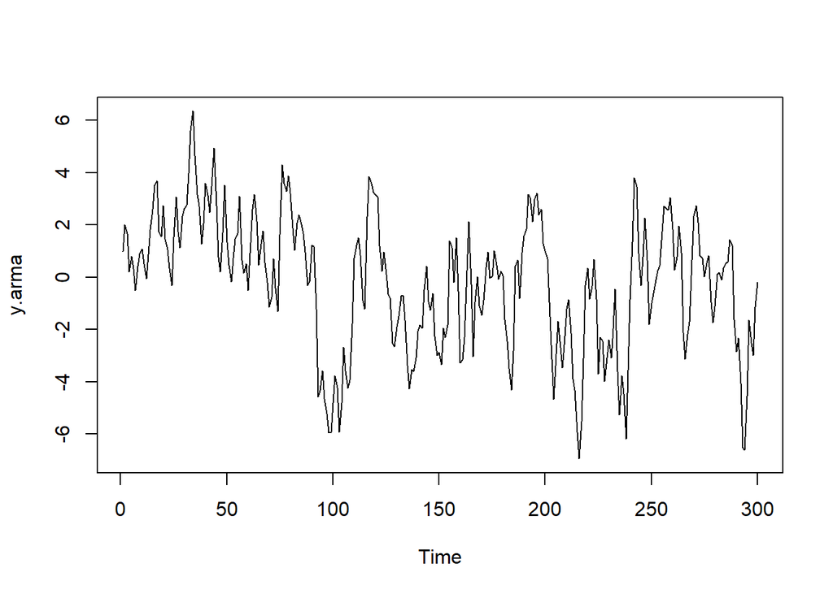

```r
ts.plot(y.arma)
```

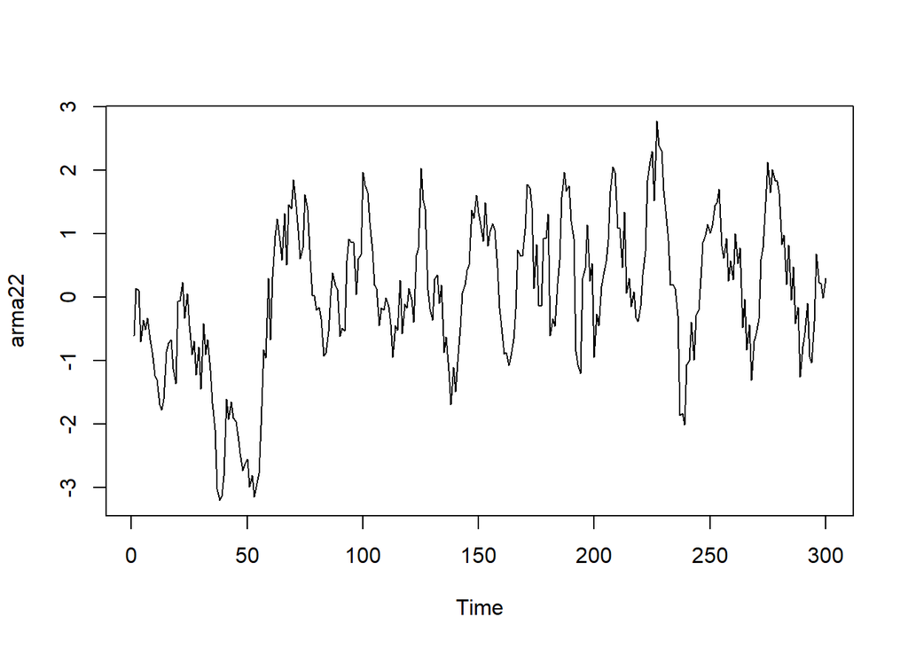

```r
ts.plot(arma22)
```

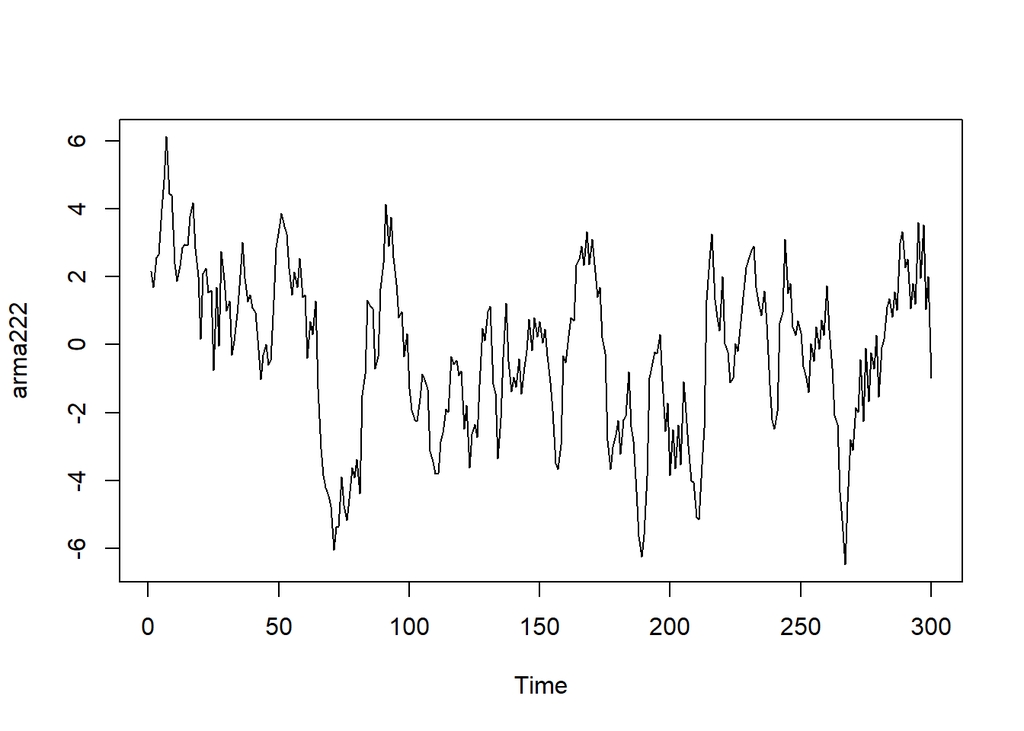

```r
ts.plot(arma222)
```

Cenderung stasioner pada rataan

### Plot ACF

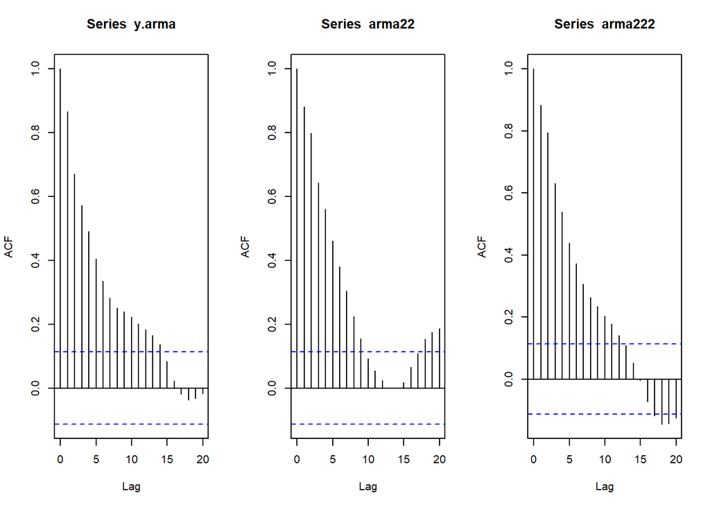

```r
par(mfrow = c(1,3))
acf(y.arma,lag.max = 20)
acf(arma22,lag.max = 20)
acf(arma222,lag.max = 20)
```

Berdasarkan plot ACF tersebut terlihat bahwa plot ACF cenderung *tails off* dan cenderung membentuk pola grafik sinus

### Plot PACF

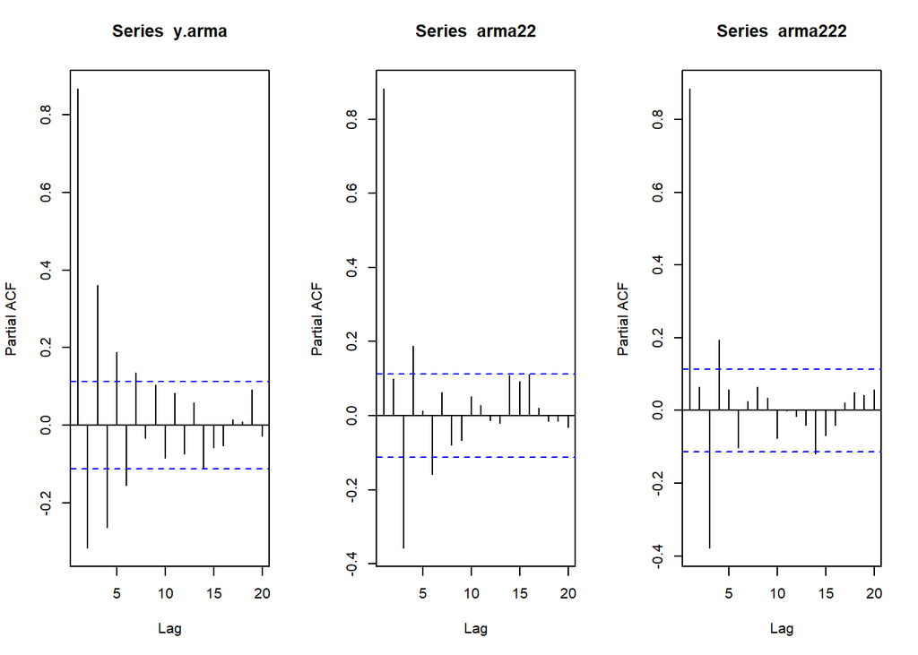

```r
par(mfrow = c(1,3))
pacf(y.arma,lag.max = 20)
pacf(arma22,lag.max = 20)
pacf(arma222,lag.max = 20)
```

Berdasarkan plot PACF tersebut terlihat bahwa plot PACF cenderung *tails off* dan cenderung membentuk pola grafik sinus

### Plot EACF

```r
TSA::eacf(y.arma)
```

```
## AR/MA
##   0 1 2 3 4 5 6 7 8 9 10 11 12 13
## 0 x x x x x x x x x x x  x  x  x
## 1 x x o o o o o o o o o  o  o  o
## 2 x x o o o o o o o o o  o  o  o
## 3 x o o o o o o o o o o  o  o  o
## 4 x x o o o o o o o o o  o  o  o
## 5 x o x o o o o o o o o  o  o  o
## 6 x o x o o x o o o o o  o  o  o
## 7 x x x x x x o o o o o  o  o  o
```

```r
TSA::eacf(arma22)
```

```
## AR/MA
##   0 1 2 3 4 5 6 7 8 9 10 11 12 13
## 0 x x x x x x x x x o o  o  o  o
## 1 o x x x o o o o o o o  o  o  o
## 2 x x o x o o o o o o o  o  o  o
## 3 x x o o o o x o o o o  o  o  o
## 4 o x x o o o x o o o o  o  o  o
## 5 o x x x o o x o o o o  o  o  o
## 6 x x x x o o o o o o o  o  o  o
## 7 x x x x o x o o o o o  o  o  o
```

```r
TSA::eacf(arma222)
```

```
## AR/MA
##   0 1 2 3 4 5 6 7 8 9 10 11 12 13
## 0 x x x x x x x x x x x  x  o  o
## 1 o x x o o o o o o o o  o  o  o
## 2 x x o o o o o o o o o  o  o  o
## 3 x x o o o o o o o o o  o  o  o
## 4 x x x x o o o o o o o  o  o  o
## 5 x x o o o o o o o o o  o  o  o
## 6 x x x o o o o o o o o  o  o  o
## 7 x x x x o x x o o o o  o  o  o
```

Berdasarkan pola segitiga nol pada plot EACF, terlihat bahwa segitiga nol berada pada ordo AR(2) dan ordo MA(2), namun pada model ARMA dengan pembangkitan menggunakan `arma.sim()` tidak terdapat ordo tersebut. Hal ini tidak sesuai teori, namun 2 dari 3 menyatakan sesuai teori.

Untuk selanjutnya akan digunakan model arma dengan pembangkitan menggunakan `arima.sim()`

### Scatter Plot antar Lag

#### Korelasi antara $Y_t$ dengan $Y_{t-1}$

```r
#Yt
yt_arma <- arma222[-1]
yt_arma
```

```
##   [1]  1.677457737  2.559677632  2.648173853  3.994254856  4.857886250
##   [6]  6.115878605  4.446276561  4.397268497  2.386984654  1.868876417
##  [11]  2.318125233  2.855299110  2.951854984  2.930114568  3.778484356
##  [16]  4.181623573  2.838737203  2.006783183  0.165239645  2.086802026
##  [21]  2.249230181  1.534719888  1.599040490 -0.757549633  1.697881548
##  [26] -0.036913058  2.738192759  1.914487157  1.000229899  1.288652449
##  [31] -0.306009559  0.102015699  0.912665125  1.733474534  3.013874482
##  [36]  1.956851153  1.269909289  1.473585036  1.074606869  0.946500149
##  [41]  0.150220186 -1.033768898 -0.297272446  0.005653387 -0.598291263
##  [46] -0.457188219  1.302803179  2.856653174  3.422383773  3.869974290
##  [51]  3.472654109  3.260754584  2.242207656  1.468517642  2.146431213
##  [56]  1.690340684  2.540401352  1.393265827  1.467038127 -0.388320388
##  [61]  0.679279351  0.286987449  1.289881386 -1.298581164 -3.054072645
##  [66] -3.853324162 -4.217414452 -4.464637175 -4.757955476 -6.045742886
##  [71] -5.376344147 -5.351323762 -3.884614038 -4.714315690 -5.161706100
```

[output cut: 45 more lines]

```r
#Yt-1
yt_1_arma <- arma222[-300]
yt_1_arma
```

```
##   [1]  2.157757288  1.677457737  2.559677632  2.648173853  3.994254856
##   [6]  4.857886250  6.115878605  4.446276561  4.397268497  2.386984654
##  [11]  1.868876417  2.318125233  2.855299110  2.951854984  2.930114568
##  [16]  3.778484356  4.181623573  2.838737203  2.006783183  0.165239645
##  [21]  2.086802026  2.249230181  1.534719888  1.599040490 -0.757549633
##  [26]  1.697881548 -0.036913058  2.738192759  1.914487157  1.000229899
##  [31]  1.288652449 -0.306009559  0.102015699  0.912665125  1.733474534
##  [36]  3.013874482  1.956851153  1.269909289  1.473585036  1.074606869
##  [41]  0.946500149  0.150220186 -1.033768898 -0.297272446  0.005653387
##  [46] -0.598291263 -0.457188219  1.302803179  2.856653174  3.422383773
##  [51]  3.869974290  3.472654109  3.260754584  2.242207656  1.468517642
##  [56]  2.146431213  1.690340684  2.540401352  1.393265827  1.467038127
##  [61] -0.388320388  0.679279351  0.286987449  1.289881386 -1.298581164
##  [66] -3.054072645 -3.853324162 -4.217414452 -4.464637175 -4.757955476
##  [71] -6.045742886 -5.376344147 -5.351323762 -3.884614038 -4.714315690
```

[output cut: 45 more lines]

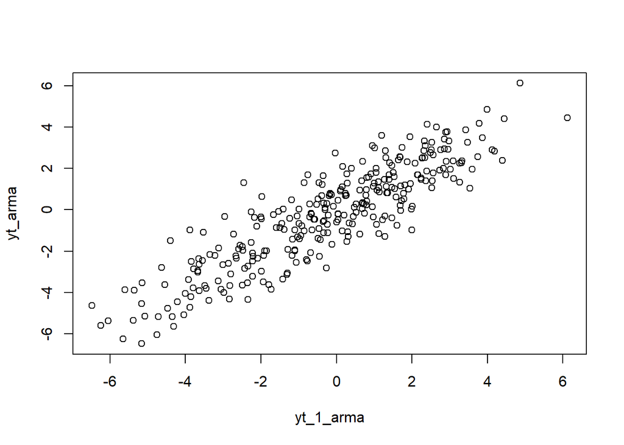

```r
plot(y=yt_arma,x=yt_1_arma)
```

Berdasarkan scatter plot, terlihat bahwa ada hubungan positif antara $Y_t$ dengan $Y_{t-1}$.

```r
cor(yt_arma,yt_1_arma)
```

```
## [1] 0.8851443
```

#### Korelasi antara $Y_t$ dengan $Y_{t-2}$

```r
#Yt
yt_arma <- arma222[-c(1,2)]
yt_arma
```

```
##   [1]  2.559677632  2.648173853  3.994254856  4.857886250  6.115878605
##   [6]  4.446276561  4.397268497  2.386984654  1.868876417  2.318125233
##  [11]  2.855299110  2.951854984  2.930114568  3.778484356  4.181623573
##  [16]  2.838737203  2.006783183  0.165239645  2.086802026  2.249230181
##  [21]  1.534719888  1.599040490 -0.757549633  1.697881548 -0.036913058
##  [26]  2.738192759  1.914487157  1.000229899  1.288652449 -0.306009559
##  [31]  0.102015699  0.912665125  1.733474534  3.013874482  1.956851153
##  [36]  1.269909289  1.473585036  1.074606869  0.946500149  0.150220186
##  [41] -1.033768898 -0.297272446  0.005653387 -0.598291263 -0.457188219
##  [46]  1.302803179  2.856653174  3.422383773  3.869974290  3.472654109
##  [51]  3.260754584  2.242207656  1.468517642  2.146431213  1.690340684
##  [56]  2.540401352  1.393265827  1.467038127 -0.388320388  0.679279351
##  [61]  0.286987449  1.289881386 -1.298581164 -3.054072645 -3.853324162
##  [66] -4.217414452 -4.464637175 -4.757955476 -6.045742886 -5.376344147
##  [71] -5.351323762 -3.884614038 -4.714315690 -5.161706100 -4.539982395
```

[output cut: 45 more lines]

```r
#Yt-2
yt_2_arma <- arma22[-c(299,300)]
yt_2_arma
```

```
##   [1] -0.60353287  0.13871462  0.11001270 -0.70067080 -0.35738654 -0.50918690
##   [7] -0.33025892 -0.66517197 -0.85932740 -1.22813235 -1.29378827 -1.69318243
##  [13] -1.76861204 -1.60063767 -0.86059966 -0.72684153 -0.67235973 -1.12885037
##  [19] -1.35609630 -0.06111744 -0.06591131  0.23430957 -0.32675580  0.05129680
##  [25] -0.45021141 -0.90469452 -0.69187227 -1.21976384 -0.78960363 -1.44504958
##  [31] -0.41647520 -0.90011683 -0.66519940 -1.14167795 -1.66774745 -2.07717775
##  [37] -3.01543357 -3.19970793 -3.13311119 -2.81591177 -1.60361785 -1.92133145
##  [43] -1.64445109 -1.90020538 -1.95469649 -2.17972577 -2.45637480 -2.73302911
##  [49] -2.63376669 -2.54923848 -2.98356728 -2.80355003 -3.14276749 -2.98689159
##  [55] -2.77618335 -2.01883981 -0.83149606 -0.95543943  0.29367637 -0.67078651
##  [61]  0.31481447  0.96748001  1.22953806  0.89420092  0.58196468  1.31582748
##  [67]  0.51644835  1.45895157  1.39742349  1.84963175  1.43893931  1.05423178
##  [73]  0.61179199  0.77256665  1.61672594  1.38366788  0.75778072  0.03370923
##  [79]  0.01954836 -0.20500310 -0.16358680 -0.33696476 -0.92189351 -0.88544405
##  [85] -0.53951596  0.01849138  0.38826804  0.19005426  0.12552786 -0.61515576
```

[output cut: 35 more lines]

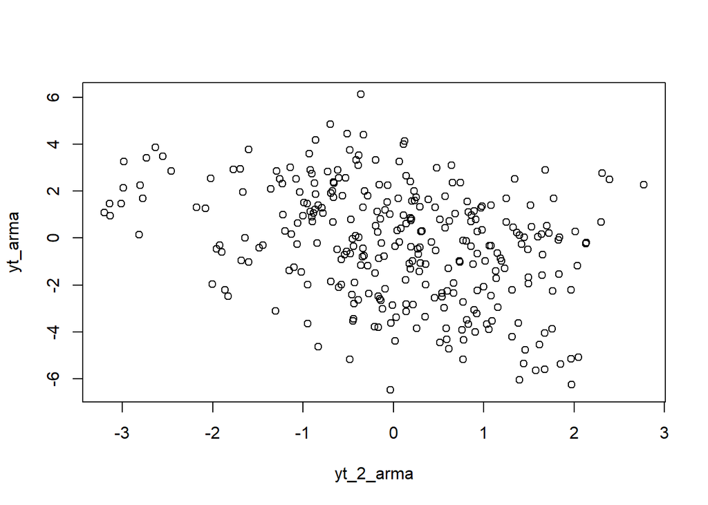

```r
plot(y=yt_arma,x=yt_2_arma)
```

```r
cor(yt_arma, yt_2_arma)
```

```
## [1] -0.3511173
```

#### Korelasi antara $Y_t$ dengan $Y_{t-3}$

```r
#Yt
yt_arma <- arma222[-c(1,2,3)]
yt_arma
```

```
##   [1]  2.648173853  3.994254856  4.857886250  6.115878605  4.446276561
##   [6]  4.397268497  2.386984654  1.868876417  2.318125233  2.855299110
##  [11]  2.951854984  2.930114568  3.778484356  4.181623573  2.838737203
##  [16]  2.006783183  0.165239645  2.086802026  2.249230181  1.534719888
##  [21]  1.599040490 -0.757549633  1.697881548 -0.036913058  2.738192759
##  [26]  1.914487157  1.000229899  1.288652449 -0.306009559  0.102015699
##  [31]  0.912665125  1.733474534  3.013874482  1.956851153  1.269909289
##  [36]  1.473585036  1.074606869  0.946500149  0.150220186 -1.033768898
##  [41] -0.297272446  0.005653387 -0.598291263 -0.457188219  1.302803179
##  [46]  2.856653174  3.422383773  3.869974290  3.472654109  3.260754584
##  [51]  2.242207656  1.468517642  2.146431213  1.690340684  2.540401352
##  [56]  1.393265827  1.467038127 -0.388320388  0.679279351  0.286987449
##  [61]  1.289881386 -1.298581164 -3.054072645 -3.853324162 -4.217414452
##  [66] -4.464637175 -4.757955476 -6.045742886 -5.376344147 -5.351323762
##  [71] -3.884614038 -4.714315690 -5.161706100 -4.539982395 -3.628471320
```

[output cut: 45 more lines]

```r
#Yt-1
yt_3_arma <- arma222[-c(298,299,300)]
yt_3_arma
```

```
##   [1]  2.157757288  1.677457737  2.559677632  2.648173853  3.994254856
##   [6]  4.857886250  6.115878605  4.446276561  4.397268497  2.386984654
##  [11]  1.868876417  2.318125233  2.855299110  2.951854984  2.930114568
##  [16]  3.778484356  4.181623573  2.838737203  2.006783183  0.165239645
##  [21]  2.086802026  2.249230181  1.534719888  1.599040490 -0.757549633
##  [26]  1.697881548 -0.036913058  2.738192759  1.914487157  1.000229899
##  [31]  1.288652449 -0.306009559  0.102015699  0.912665125  1.733474534
##  [36]  3.013874482  1.956851153  1.269909289  1.473585036  1.074606869
##  [41]  0.946500149  0.150220186 -1.033768898 -0.297272446  0.005653387
##  [46] -0.598291263 -0.457188219  1.302803179  2.856653174  3.422383773
##  [51]  3.869974290  3.472654109  3.260754584  2.242207656  1.468517642
##  [56]  2.146431213  1.690340684  2.540401352  1.393265827  1.467038127
##  [61] -0.388320388  0.679279351  0.286987449  1.289881386 -1.298581164
##  [66] -3.054072645 -3.853324162 -4.217414452 -4.464637175 -4.757955476
##  [71] -6.045742886 -5.376344147 -5.351323762 -3.884614038 -4.714315690
```

[output cut: 45 more lines]

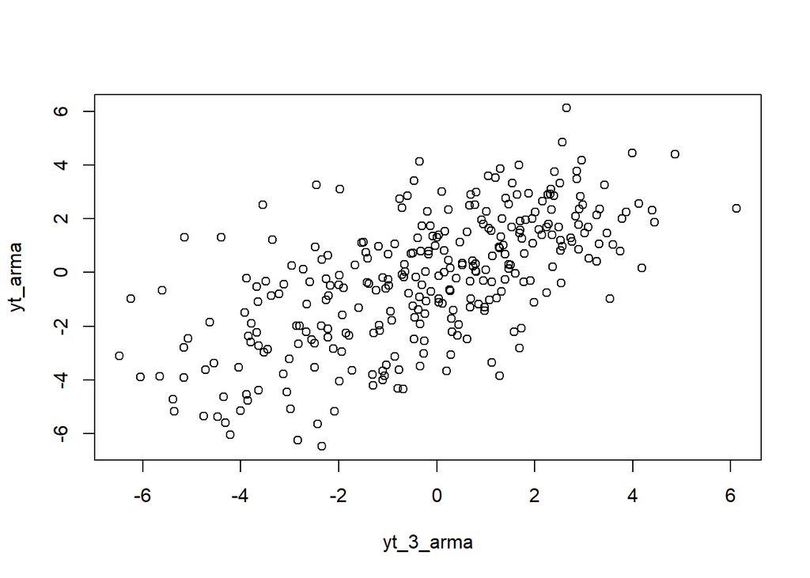

```r
plot(y=yt_arma,x=yt_3_arma)
```

Berdasarkan scatter plot, terdapat hubungan positif antara $Y_t$ dengan $Y_{t-3}$

```r
cor(yt_arma, yt_3_arma)
```

```
## [1] 0.6353487
```